# Kausal inferens - Lecture 1: Simple Regression

About linear regression.

Nora Jones  
2021-09-13

## Simple regression

### Steps for empirisk analyse

1. Opstil spørgsmål.
2. Opsæt en teoretisk model.
3. Lav modellen om til en econometric model.
4. Saml data, estimer parameter, lav konfidens intervaller og test hypotese.

### Data typer

- **Cross sectional data** samlet for individer, firmer på et tidspunkt.
- **Panel data** samling af individer, firmar over flere periode.
- **Time series**: En enkelt individe, firma over en årrække.

### Issues

1. Hvordan tillader vi andre faktor end x kan påvirke y?
2. Hvad er den **funktionalle forhold** mellem y og x?
3. Hvordan kan vi fange **ceteris paribus relationship** mellem y og x og derved få et causal forhold?

### Assumption

**Zero conditional mean assumption**:

$$E(u|x)=0$$

**Population regression function**

$$E(y|x)=\beta_0+\beta_1$$

Vores fokus er den *kausale effekt* af x på y altså **average causal effekt**. Derfor skal vi se på den partial derivative:

$$\frac{\partial E(y|x)}{\partial x} = \frac{\partial}{\partial x }(\beta_0+\beta_1 x)=\beta_1$$

### Sample analogs and method of moments

$$\hat \beta=\bar y - \hat \beta _1 \bar x$$

$$\hat \beta_1 =\frac{\text{Sample covariance}(x_i,y_i)}{\text{Sample variance}(x_i)}$$

### OLS

**fitted value** er vores predict for y

$$\hat y_i = \hat \beta _0 + \hat \beta _1 x$$
Hvor vi så har **residual**

$$\hat u_i = y_i - \hat y_i$$

Hvor vi kan skrive: $\hat y_i = \hat \beta _0 + \hat \beta _1 x$.

### Interpretation of $\beta_1$

| Model | Change in dependent variable | change in regessor |
| --- | --- | --- |
| Level level | $\beta_1$ units | 1 unit |
| Level log | $\beta_1/100$ units | 1 % |
| log level | $100 \beta_1$ units | 1 unit |
| log log | $\beta_1$ % | 1 % |

### Linear meaning

Det betyder at parameterne beta0 og beta1 er lineær.

### SLR assumption Gauss Markov

- **SLR. 1**: Linear i parameter.
- **SLR. 2**: Random sampling.
- **SLR. 3**: Sample variation in $x_i$.
- **SLR. 4**: Zero conditional mean: error term has zero mean.

### Monte Carlo Simulering

$$x \sim Unifrom(-2,2) \\
u\sim normal(0,1)$$

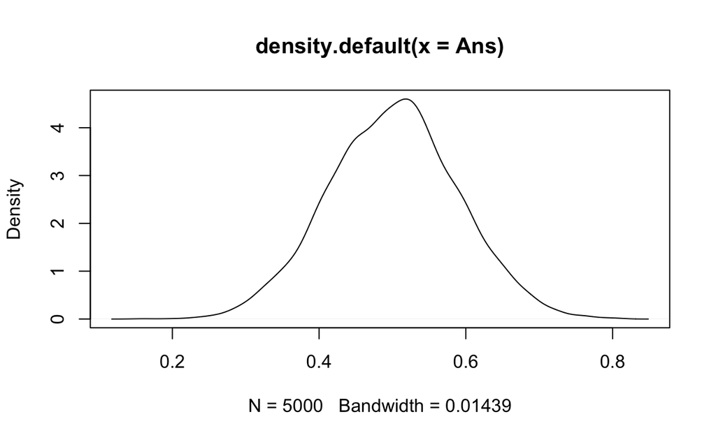

- **SLR . 5**: Homoskedastic.